# framework GPP in lake ecosystems and phytoplankton stoichiometry

Daniel Gschwentner

2024-07-16

## Introduction

### Experiment 1

- We hypothesized that increasing N and P loads would result in higher rates of GPP but that GPP would be constrained by the relative supply of N and P. That is GPP should be low at extremely high and low inflow N:P ratios. We hypothesized that luxury uptake of N and P would result in more complex patterns of GPP.
- We hypothesized that phytoplankton N:P would increase and decrease respectively with increasing inflow N and P concentrations, and that the ability for luxury uptake of N and P would produce extremely high and low N:P phytoplankton stoichiometry.

### Experiment 2

We explored how GPP varied as inflow concentrations of P and N changed in correlated ways (i.e. N:P is fixed). We ran scenarios in which we increased inflow P concentrations from 0.005 to 0.500 g P m<sup>-3</sup> and varied inflow concentrations at N:P mass ratios of 90.44, 22.61, 7.24, 2.26 (molar ratios of 200, 50, 16, 5).

- We hypothesized that we would observe the highest levels of GPP when loads where stoichiometrically balanced (i.e. close to Redfield ratio of 7.24 N:P by mass), and that GPP would decrease with increasing and decreasing N:P from Redfield.

### Experiment 3

We examined how different phytoplankton groups influenced GPP. For this, we re-ran simulations from experiments 1 and 2 with models populated with 3 phytoplankton groups (diatoms, green algae, cyanobacteria) which have different trait values.

Diatoms, greens, cyanos comparison

### Experiment 4

Explore variation in phytoplankton traits; still working on this.

## Setup

The chunks in this section load packages, models and data needed to run the models.

This chunk creates lists of parameters needed to run the models. In total, there are 8 parameter lists:

- Michaelis-Menten model for average, diatom, greens and cyano traits
- Droop model for average, diatom, greens and cyano traits

These parameter lists require the table with phytoplankton traits from [Edwards et al., 2016](https://figshare.com/articles/dataset/Data_Paper_Data_Paper/3562857?file=5635515) data set. The code will need to be updated if the format of the table changes in any way.

## Running models (can ignore this)

The next couple of code chunks run the models for the different simulations/experiments described in the introduction section. They shouldn’t produce any visible output, and you shouldn’t have to touch any of the code.

### Experiment 1

Run models using Michaelis-Menten and Droop formulation and **average** phytoplankton traits across simulatenously varying N and P loads.

### Experiment 2

Run models using Michaelis-Menten and Droop formulation and **average** phytoplankton traits across varying P loads and **fixed** N:P stoichiometry of 90.44, 22.61, 7.24, 2.26 by mass..

### Experiment 3

Experiment 3 re-runs experiments 1 and 2 for the three phytoplankton groups.

#### Experiment 3 pt 1

#### Experiment 3 pt 2

## Output

### Output for experiment 1

Lake GPP increased with N and P inflow concentrations. Clear stoichiometric patterns for both model expressions where extreme inflow N:P ratios result in nutrient limitation. The areas of the plot where limitation occurs fall very close to the Redfield ratio (white line in figures). This is pretty cool but not necessarily novel? The Michaelis-Menten model creates step-wise changes in GPP whereas the Droop model is “smoother”.

The changes in seston C:N are pretty intuitive: decreasing N:P of the inflow increases C:N (i.e. phytos accumulate C but not N, become strongly N limited), and vice versa for increasing N:P and C:P. There is a relatively narrow range of C:N compared to C:P or even N:P.

I think these results generically support stoichiometric theory; imbalanced N:P supply results in luxury uptake of the non-limiting nutrient; nutrient limitation increases C:X ratios.

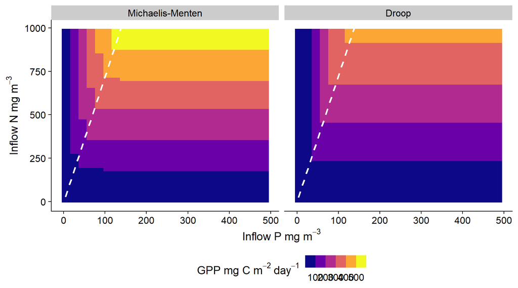

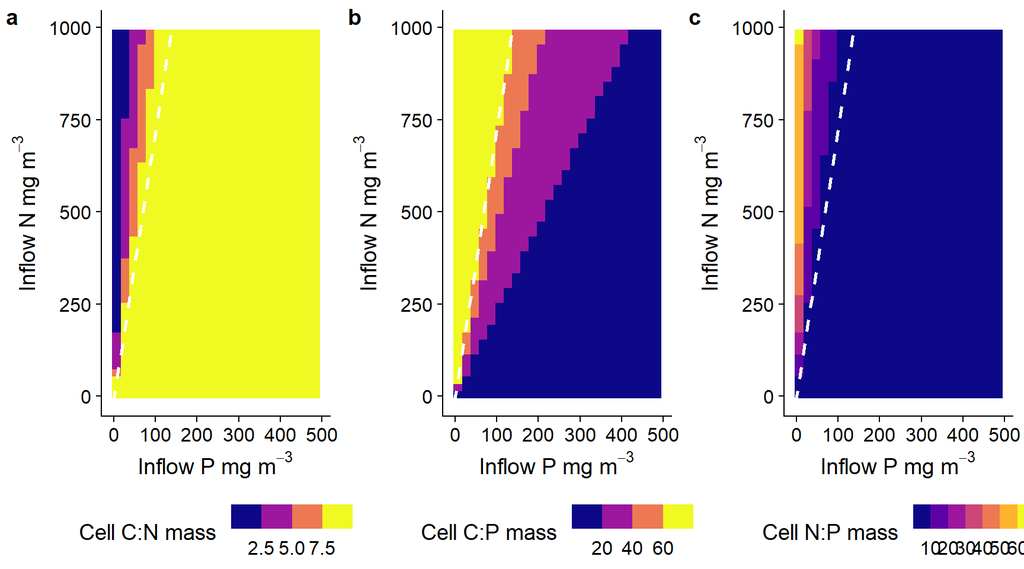

### Output for experiment 2

**Note: For some reason the legend isn’t rendering in my Markdown file. FYI the color legend shows increasing N:P of the inflow/supply by mass.**

This is where stuff gets interesting! While GPP increases with P inflow concentrations, stoichiometry constrains increases in biomass once the N:P of the inflow exceeds 23 by mass in biomass (approximately 50 by moles)! There should be a fourth line in orange in the first figure which overlaps with the yellow line. The Droop model produces lower estimates of GPP on average.

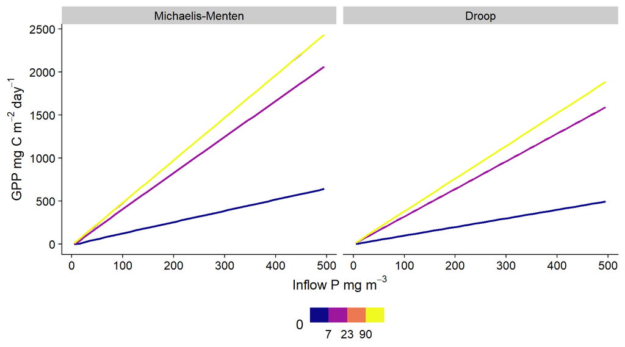

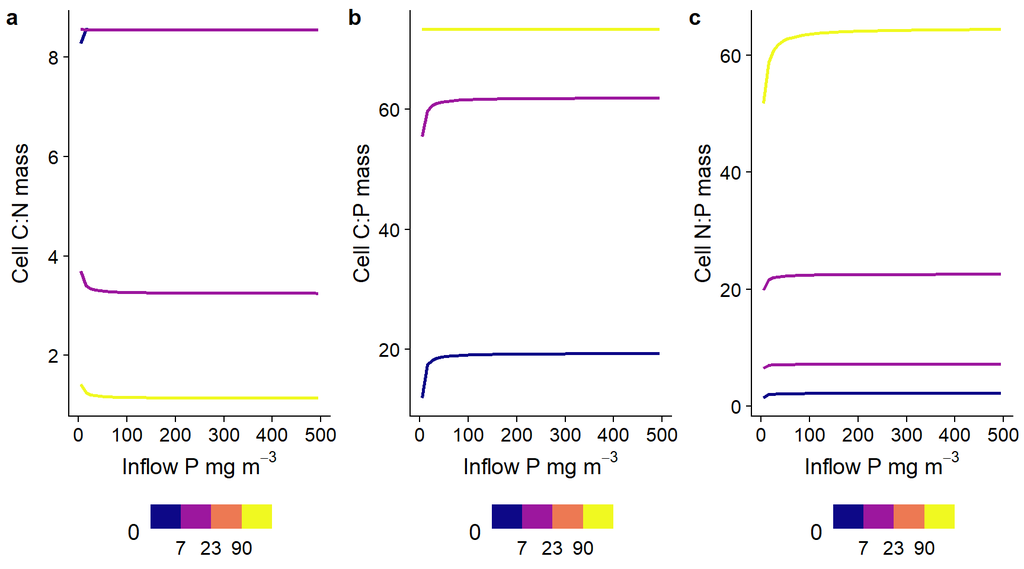

### Output for experiment 3

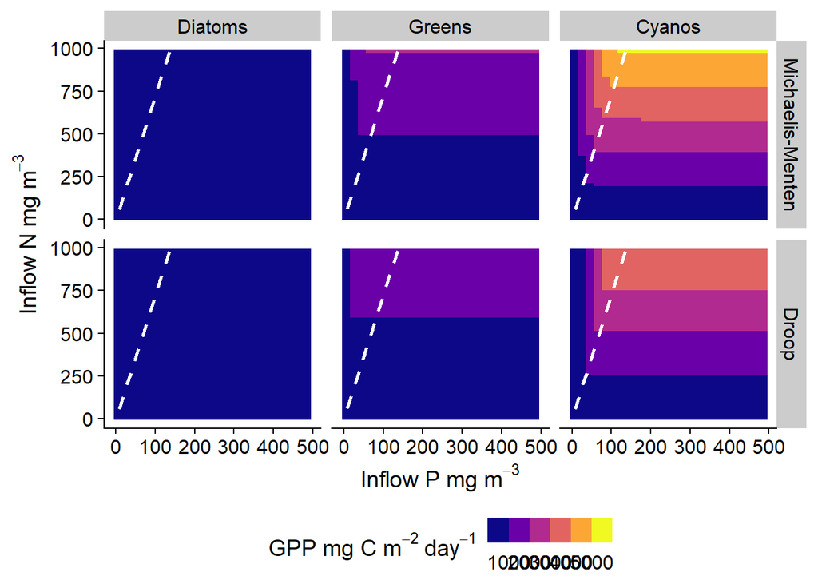

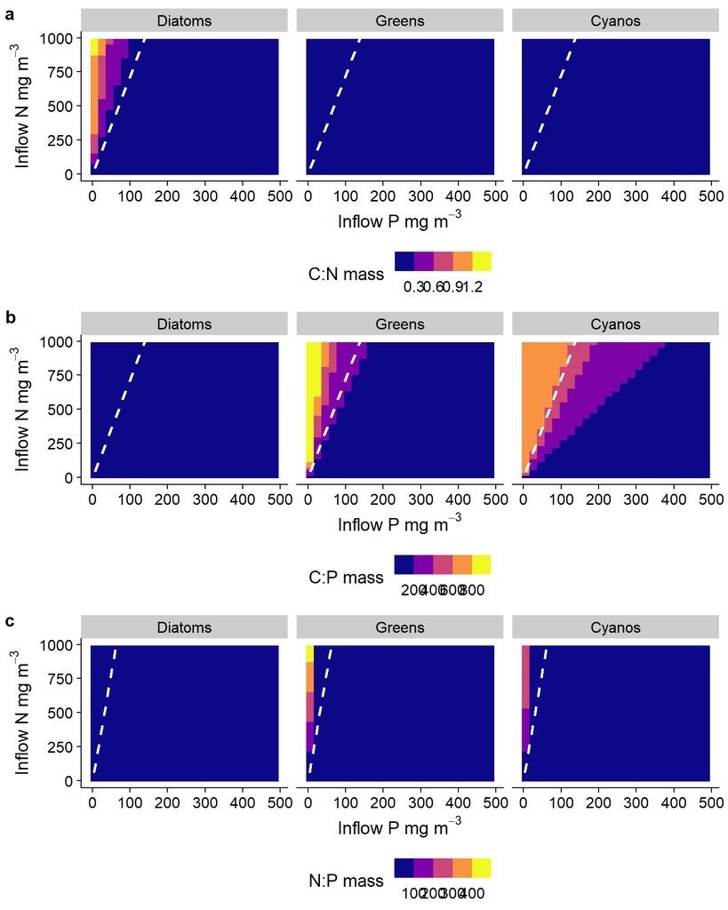

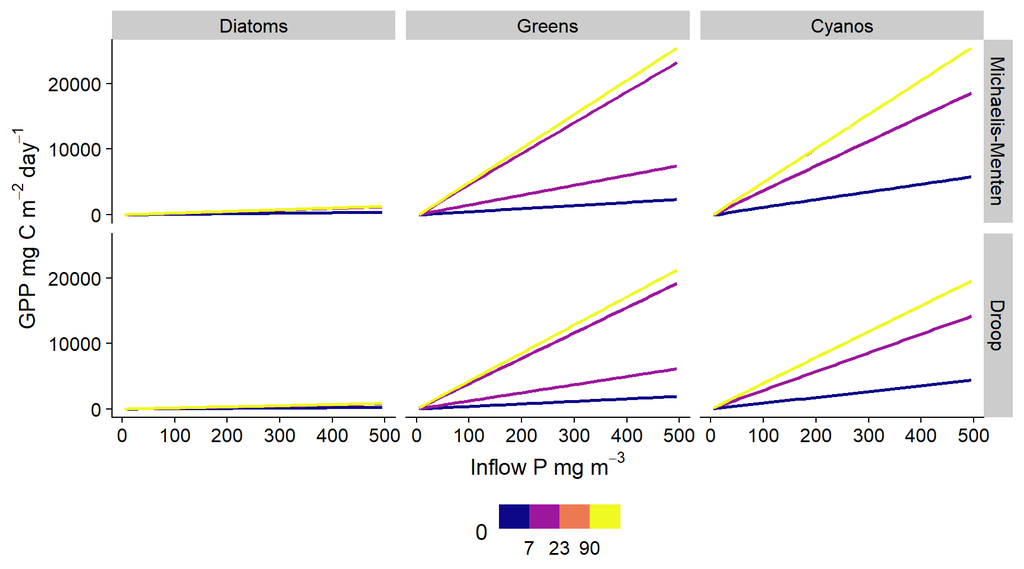

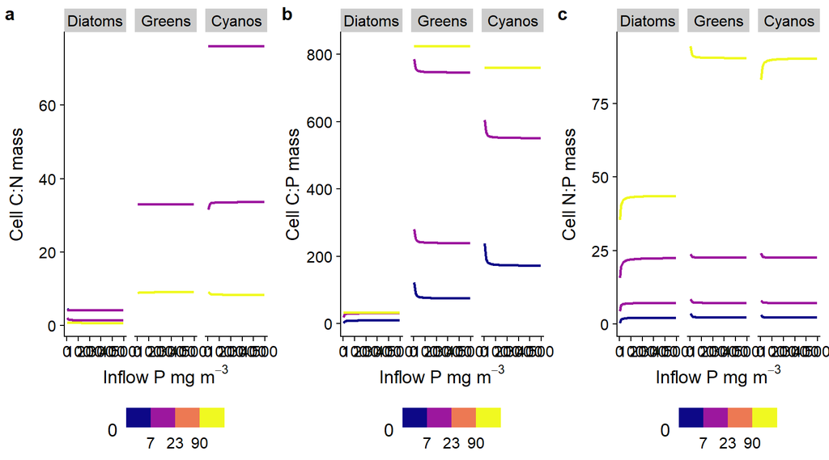

## Ternary plots

I managed to generate ternary plots from the model outputs using the ‘ggtern’ package. Not sure how informative these figures are; the Redfield ratio is included as a back dot in each of the plots, and you can see how observations move towards or away from Redfield depending on the scenario.

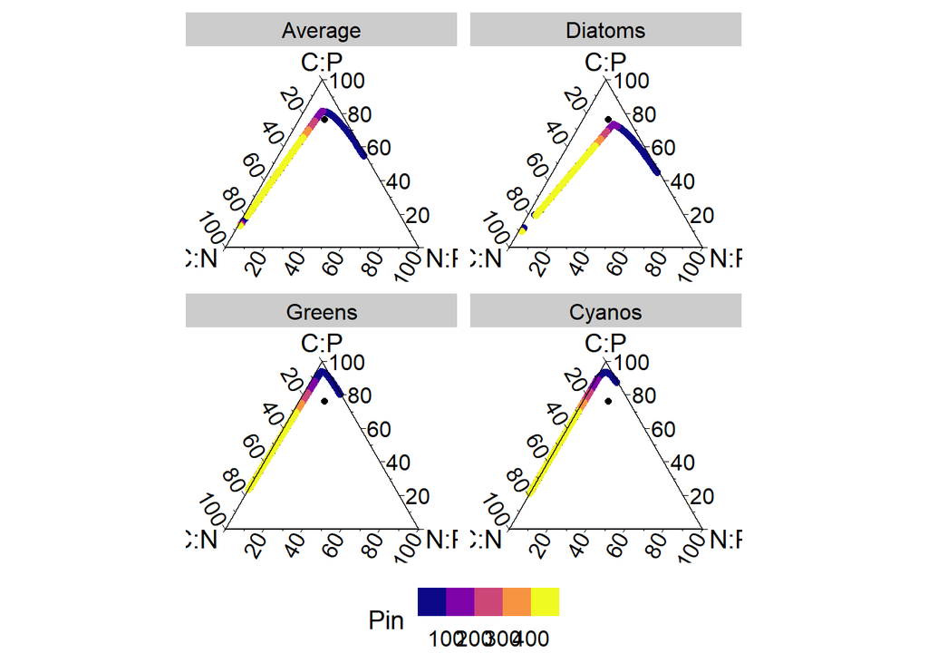

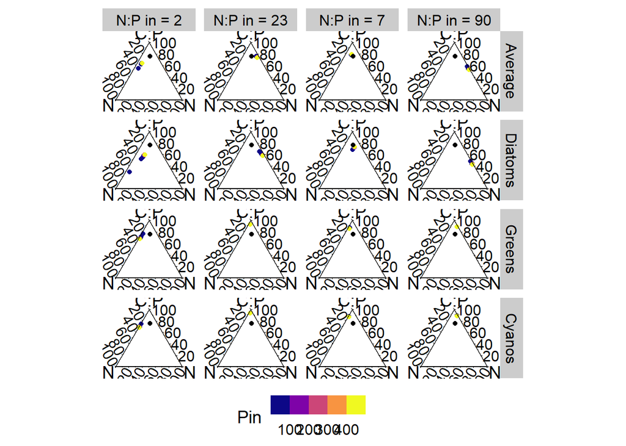